# COVID-19 in Thailand Analysis

## By: Pattadon Naksuwan

First, import the data from https://data.go.th/dataset/covid-19-testing-data.

```python
import pandas as pd

url = "https://data.go.th/dataset/9f6d900f-f648-451f-8df4-89c676fce1c4/resource/0092046c-db85-4608-b519-ce8af099315e/download/thailand_covid-19_testing_data_update280864.csv"

df = pd.read_csv(url)
df
```

|  | Date | positive | Total Testing | Unnamed: 3 | Unnamed: 4 | Unnamed: 5 | Unnamed: 6 | Unnamed: 7 | Unnamed: 8 | Unnamed: 9 | ... | Unnamed: 112 | Unnamed: 113 | Unnamed: 114 | Unnamed: 115 | Unnamed: 116 | Unnamed: 117 | Unnamed: 118 | Unnamed: 119 | Unnamed: 120 | Unnamed: 121 |
| --- | --- | --- | --- | --- | --- | --- | --- | --- | --- | --- | --- | --- | --- | --- | --- | --- | --- | --- | --- | --- | --- |
| 0 | Cannot specify date | 2963 | 32131 | NaN | NaN | NaN | NaN | NaN | NaN | NaN | ... | NaN | NaN | NaN | NaN | NaN | NaN | NaN | NaN | NaN | NaN |
| 1 | 1/1/2020 | 0 | 0 | NaN | NaN | NaN | NaN | NaN | NaN | NaN | ... | 27 | NaN | 28 | NaN | 29 | NaN | 30 | NaN | 31 | NaN |
| 2 | 2/1/2020 | 0 | 0 | NaN | NaN | NaN | NaN | NaN | NaN | NaN | ... | Pos | Total | Pos | Total | Pos | Total | Pos | Pos | Pos | Pos |
| 3 | 3/1/2020 | 0 | 0 | NaN | NaN | NaN | NaN | NaN | NaN | NaN | ... | NaN | NaN | NaN | NaN | NaN | NaN | NaN | NaN | NaN | NaN |
| 4 | 4/1/2020 | 0 | 2 | NaN | NaN | NaN | NaN | NaN | NaN | NaN | ... | NaN | NaN | NaN | NaN | NaN | NaN | NaN | NaN | NaN | NaN |
| ... | ... | ... | ... | ... | ... | ... | ... | ... | ... | ... | ... | ... | ... | ... | ... | ... | ... | ... | ... | ... | ... |
| 602 | 24/8/2021 | 12838 | 64284 | NaN | NaN | NaN | NaN | NaN | NaN | NaN | ... | NaN | NaN | NaN | NaN | NaN | NaN | NaN | NaN | NaN | NaN |
| 603 | 25/8/2021 | 13670 | 62160 | NaN | NaN | NaN | NaN | NaN | NaN | NaN | ... | NaN | NaN | NaN | NaN | NaN | NaN | NaN | NaN | NaN | NaN |
| 604 | 26/8/2021 | 11911 | 59708 | NaN | NaN | NaN | NaN | NaN | NaN | NaN | ... | NaN | NaN | NaN | NaN | NaN | NaN | NaN | NaN | NaN | NaN |
| 605 | 27/8/2021 | 9124 | 50388 | NaN | NaN | NaN | NaN | NaN | NaN | NaN | ... | NaN | NaN | NaN | NaN | NaN | NaN | NaN | NaN | NaN | NaN |
| 606 | 28/8/2021 | 8694 | 42463 | NaN | NaN | NaN | NaN | NaN | NaN | NaN | ... | NaN | NaN | NaN | NaN | NaN | NaN | NaN | NaN | NaN | NaN |

607 rows × 122 columns

## Data Wrangling

There are some NaN values, which we don't want them.

```python
df.isnull().sum()
```

```
Date               0
positive           0
Total Testing      0
Unnamed: 3       607
Unnamed: 4       607
                ...
Unnamed: 117     606
Unnamed: 118     605
Unnamed: 119     606
Unnamed: 120     605
Unnamed: 121     606
Length: 122, dtype: int64
```

So, we will drop columns that contain NaN values.

```python
df.dropna(axis='columns', inplace=True)
df
```

|  | Date | positive | Total Testing |
| --- | --- | --- | --- |
| 0 | Cannot specify date | 2963 | 32131 |
| 1 | 1/1/2020 | 0 | 0 |
| 2 | 2/1/2020 | 0 | 0 |
| 3 | 3/1/2020 | 0 | 0 |
| 4 | 4/1/2020 | 0 | 2 |
| ... | ... | ... | ... |
| 602 | 24/8/2021 | 12838 | 64284 |
| 603 | 25/8/2021 | 13670 | 62160 |
| 604 | 26/8/2021 | 11911 | 59708 |
| 605 | 27/8/2021 | 9124 | 50388 |
| 606 | 28/8/2021 | 8694 | 42463 |

607 rows × 3 columns

Create new column for positive rate

```python
df['positive case rate'] = df['positive']/df['Total Testing']
df
```

|  | Date | positive | Total Testing | positive case rate |
| --- | --- | --- | --- | --- |
| 0 | Cannot specify date | 2963 | 32131 | 0.092216 |
| 1 | 1/1/2020 | 0 | 0 | NaN |
| 2 | 2/1/2020 | 0 | 0 | NaN |
| 3 | 3/1/2020 | 0 | 0 | NaN |
| 4 | 4/1/2020 | 0 | 2 | 0.000000 |
| ... | ... | ... | ... | ... |
| 602 | 24/8/2021 | 12838 | 64284 | 0.199708 |
| 603 | 25/8/2021 | 13670 | 62160 | 0.219916 |
| 604 | 26/8/2021 | 11911 | 59708 | 0.199488 |
| 605 | 27/8/2021 | 9124 | 50388 | 0.181075 |
| 606 | 28/8/2021 | 8694 | 42463 | 0.204743 |

607 rows × 4 columns

What date has the most total testing cases?

```python
df['Total Testing'].max()
df[df['Total Testing']==df['Total Testing'].max()]
```

|  | Date | positive | Total Testing | positive case rate |
| --- | --- | --- | --- | --- |
| 568 | 21/7/2021 | 12210 | 82325 | 0.148315 |

```python
df[df['positive case rate']==df['positive case rate'].max()]
```

|  | Date | positive | Total Testing | positive case rate |
| --- | --- | --- | --- | --- |
| 8 | 8/1/2020 | 1 | 1 | 1.0 |

## Data Visualization

### Now, let's try to plot some graphs

```python
import plotly.express as px
import plotly
```

```python
fig = px.bar(x=df['Date'], y=df['positive case rate'], title="COVID-19 positive case rate")
fig.show()
```

[interactive chart not shown]

This is an interactive bar chart. You can see the detail when you hover the bar.

If we want to visualize and analyse only in 2021, we have to create a new data frame.

```python
df = df.set_index('Date')
df_2021 = df.loc['1/1/2021':]
```

```python
df_2021 = df_2021.reset_index()
df = df.reset_index()
```

Extract month from date, then create a new cloumn called 'month'.

```python
month_list = []
for date in df_2021['Date']:
    month=date.split('/')[1]
    month_list.append(month)
month_list
```

```
['1',
 '1',
 '1',
 '1',
 '1',
 '1',
 '1',
 '1',
 '1',
 '1',
 '1',
 '1',
 '1',
 '1',
 '1',
 '1',
 '1',
 '1',
 '1',
 '1',
 '1',
 '1',
 '1',
 '1',
 '1',
 '1',
 '1',
 '1',
 '1',
 '1',
 '1',
 '2',
 '2',
 '2',
 '2',
 '2',
 '2',
 '2',
 '2',
 '2',
```

[output cut: 185 more lines]

```
 '8',
 '8',
 '8',
 '8',
 '8',
 '8',
 '8',
 '8',
 '8',
 '8',
 '8',
 '8',
 '8',
 '8',
 '8']
```

```python
df_2021
df_2021['month'] = month_list
```

```python
fig = px.bar(df_2021, x="Date", y="positive case rate", title="COVID-19 positive case rate")
fig.show()
```

[interactive chart not shown]

Now, we want to visualize covid-19 cases month by month.

```python
bar_data = df_2021.groupby(['month']).sum()
```

```python
bar_data['positive case rate'] = bar_data['positive']/bar_data['Total Testing']
bar_data
```

| month | positive | Total Testing | positive case rate |
| --- | --- | --- | --- |
| 1 | 5691 | 726255 | 0.007836 |
| 2 | 4070 | 432329 | 0.009414 |
| 3 | 3353 | 490937 | 0.006830 |
| 4 | 50713 | 1472004 | 0.034452 |
| 5 | 86341 | 1957460 | 0.044109 |
| 6 | 110890 | 1853392 | 0.059831 |
| 7 | 297539 | 2018433 | 0.147411 |
| 8 | 383283 | 1621139 | 0.236428 |

```python
bar_data = bar_data.reset_index()
fig = px.bar(bar_data, x="month", y="positive case rate", title="COVID-19 positive case rate")
fig.show()
```

[interactive chart not shown]

```python
fig = px.bar(bar_data, x='month', y='positive', title="COVID-19 positive cases")
fig.show()
```

[interactive chart not shown]

To see the proportion, we need pie chart.

```python
fig = px.pie(bar_data, values='positive', names='month', title="COVID-19 case proportion of 2021")
fig.show()
```

[interactive chart not shown]

## Correlation

Checking data type of each columns

```python
bar_data.dtypes
```

```
month                  object
positive                int64
Total Testing           int64
positive case rate    float64
dtype: object
```

You can see that month is now an object data type, so we need to change it to int.

```python
bar_data[["month"]] = bar_data[["month"]].apply(pd.to_numeric)
bar_data.dtypes
```

```
month                   int64
positive                int64
Total Testing           int64
positive case rate    float64
dtype: object
```

```
(0.0, 413496.39329313074)
```

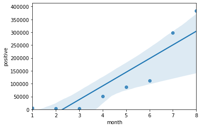

```python
import matplotlib.pyplot as plt
import seaborn as sns
sns.regplot(x="month",y="positive", data = bar_data)
plt.ylim(0,)
```

```python
from scipy import stats
pearson_coef, p_value = stats.pearsonr(bar_data['month'], bar_data['positive'])
print("Pearson_coef: "+str(pearson_coef))
print("p-value: "+str(p_value))
```

```
Pearson_coef: 0.8994547246342198
p-value: 0.0023533492757691777
```

#### Pearson Correlation

measures the strength of the correlation between 2 features

In this case, p-value is moderate certainty and the linear relationship is stong.

```python
bar_data[['month','positive']].corr()
```

|  | month | positive |
| --- | --- | --- |
| month | 1.000000 | 0.899455 |
| positive | 0.899455 | 1.000000 |

## Applying linear regression model

```python
from sklearn.linear_model import LinearRegression
lm = LinearRegression()
```

```python
x = bar_data[['month']]
y = bar_data[['positive']]
lm.fit(x,y)
```

```
LinearRegression()
```

```python
print("intercept: "+str(lm.intercept_))
print("coefficient: "+str(lm.coef_))
```

```
intercept: [-121661.14285714]
coefficient: [[53199.14285714]]
```

```python
yhat = lm.predict(x)
yhat_compare = pd.DataFrame(yhat[0:5])
yhat_compare.rename(columns={0: "yhat"})
```

|  | yhat |
| --- | --- |
| 0 | -68462.000000 |
| 1 | -15262.857143 |
| 2 | 37936.285714 |
| 3 | 91135.428571 |
| 4 | 144334.571429 |

```python
y[0:5]
```

|  | positive |
| --- | --- |
| 0 | 5691 |
| 1 | 4070 |
| 2 | 3353 |
| 3 | 50713 |
| 4 | 86341 |

Now, you can compare the predicted values with the real values.

Make a function to compute the predicted value

```python
intercept = lm.intercept_[0]
coef = lm.coef_[0][0]
def predict_case(x):
    return coef*x+intercept
```

```python
predict_case(9)
```

```
357131.14285714296
```

## Model Evaluation

two main measures

- MSE: Mean Squared Error
- R-squared: Percentage of variation of the target variable

```python
from sklearn.metrics import mean_squared_error
print("MSE: "+str(mean_squared_error(bar_data['positive'], yhat)))
```

```
MSE: 3507523364.892858
```

```python
print("R-squared: ",str(lm.score(x,y)))
```

```
R-squared:  0.8090188016668205
```

This mini-project is just for personal experiment.

Thank you